# Assignment5: Mushroom Edibility Association Rules Analysis

Jaume Adrover Fernandez, Joan Balaguer Llagostera

2023-12-25

## Objective of the Analysis

The objective of this analysis is to discover association rules within a dataset of mushroom characteristics to differentiate between edible and poisonous mushrooms. Specifically, we aim to:

1. **Identify Key Characteristics:**
   - Determine which attributes (e.g., color, shape, odor) are most strongly associated with mushrooms being edible or poisonous.
2. **Understand Patterns of Edibility:**
   - Uncover patterns and combinations of features that commonly occur in edible mushrooms, as well as those that are indicative of poisonous varieties.
3. **Optimize Rule Discovery:**
   - Experiment with different parameters such as minimum support, minimum confidence, and rule length to find the most significant and relevant rules.
4. **Eliminate Redundancy:**
   - Identify and remove redundant rules to ensure that the final set of rules is both concise and informative.
5. **Provide Conclusions:**
   - Summarize the findings in a way that enhances understanding of mushroom edibility based on observable characteristics and contributes valuable insights for potential applications, such as in culinary use or educational purposes.

## Data Exploration and Preprocessing

First of all, we will import our dataset and take a look at the dataset structure and the type of variables that has on it.

```r
# Load the dataset
mushrooms <- read.csv("mushrooms.csv")

# Show the first few rows of the dataset
head(mushrooms)
```

```
##        type cap_shape cap_surface cap_color bruises    odor gill_attachment
## 1 poisonous    convex      smooth     brown     yes pungent            free
## 2    edible    convex      smooth    yellow     yes  almond            free
## 3    edible      bell      smooth     white     yes   anise            free
## 4 poisonous    convex       scaly     white     yes pungent            free
## 5    edible    convex      smooth      gray      no    none            free
## 6    edible    convex       scaly    yellow     yes  almond            free
##   gill_spacing gill_size gill_color stalk_shape stalk_root
## 1        close    narrow      black   enlarging      equal
## 2        close     broad      black   enlarging       club
## 3        close     broad      brown   enlarging       club
## 4        close    narrow      brown   enlarging      equal
## 5      crowded     broad      black    tapering      equal
## 6        close     broad      brown   enlarging       club
##   stalk_surface_above_ring stalk_surface_below_ring stalk_color_above_ring
```

[output cut: 20 more lines]

```r
# Summary of each variable
summary(mushrooms)
```

```
##      type            cap_shape         cap_surface         cap_color
##  Length:8124        Length:8124        Length:8124        Length:8124
##  Class :character   Class :character   Class :character   Class :character
##  Mode  :character   Mode  :character   Mode  :character   Mode  :character
##    bruises              odor           gill_attachment    gill_spacing
##  Length:8124        Length:8124        Length:8124        Length:8124
##  Class :character   Class :character   Class :character   Class :character
##  Mode  :character   Mode  :character   Mode  :character   Mode  :character
##   gill_size          gill_color        stalk_shape         stalk_root
##  Length:8124        Length:8124        Length:8124        Length:8124
##  Class :character   Class :character   Class :character   Class :character
##  Mode  :character   Mode  :character   Mode  :character   Mode  :character
##  stalk_surface_above_ring stalk_surface_below_ring stalk_color_above_ring
##  Length:8124              Length:8124              Length:8124
##  Class :character         Class :character         Class :character
##  Mode  :character         Mode  :character         Mode  :character
##  stalk_color_below_ring  veil_type          veil_color
##  Length:8124            Length:8124        Length:8124
##  Class :character       Class :character   Class :character
##  Mode  :character       Mode  :character   Mode  :character
##  ring_number         ring_type         spore_print_color   population
##  Length:8124        Length:8124        Length:8124        Length:8124
##  Class :character   Class :character   Class :character   Class :character
##  Mode  :character   Mode  :character   Mode  :character   Mode  :character
##    habitat
##  Length:8124
##  Class :character
##  Mode  :character
```

```r
# Check the structure of the dataset
str(mushrooms)
```

```
## 'data.frame':    8124 obs. of  23 variables:
##  $ type                    : chr  "poisonous" "edible" "edible" "poisonous" ...
##  $ cap_shape               : chr  "convex" "convex" "bell" "convex" ...
##  $ cap_surface             : chr  "smooth" "smooth" "smooth" "scaly" ...
##  $ cap_color               : chr  "brown" "yellow" "white" "white" ...
##  $ bruises                 : chr  "yes" "yes" "yes" "yes" ...
##  $ odor                    : chr  "pungent" "almond" "anise" "pungent" ...
##  $ gill_attachment         : chr  "free" "free" "free" "free" ...
##  $ gill_spacing            : chr  "close" "close" "close" "close" ...
##  $ gill_size               : chr  "narrow" "broad" "broad" "narrow" ...
##  $ gill_color              : chr  "black" "black" "brown" "brown" ...
##  $ stalk_shape             : chr  "enlarging" "enlarging" "enlarging" "enlarging" ...
##  $ stalk_root              : chr  "equal" "club" "club" "equal" ...
##  $ stalk_surface_above_ring: chr  "smooth" "smooth" "smooth" "smooth" ...
##  $ stalk_surface_below_ring: chr  "smooth" "smooth" "smooth" "smooth" ...
##  $ stalk_color_above_ring  : chr  "white" "white" "white" "white" ...
##  $ stalk_color_below_ring  : chr  "white" "white" "white" "white" ...
##  $ veil_type               : chr  "partial" "partial" "partial" "partial" ...
##  $ veil_color              : chr  "white" "white" "white" "white" ...
##  $ ring_number             : chr  "one" "one" "one" "one" ...
##  $ ring_type               : chr  "pendant" "pendant" "pendant" "pendant" ...
##  $ spore_print_color       : chr  "black" "brown" "brown" "black" ...
##  $ population              : chr  "scattered" "numerous" "numerous" "scattered" ...
##  $ habitat                 : chr  "urban" "grasses" "meadows" "urban" ...
```

After taking a look at the dataset structure, we are going to check for missing values:

```r
# Check for missing values
colSums(is.na(mushrooms))
```

```
##                     type                cap_shape              cap_surface
##                        0                        0                        0
##                cap_color                  bruises                     odor
##                        0                        0                        0
##          gill_attachment             gill_spacing                gill_size
##                        0                        0                        0
##               gill_color              stalk_shape               stalk_root
##                        0                        0                        0
## stalk_surface_above_ring stalk_surface_below_ring   stalk_color_above_ring
##                        0                        0                        0
##   stalk_color_below_ring                veil_type               veil_color
##                        0                        0                        0
##              ring_number                ring_type        spore_print_color
##                        0                        0                        0
##               population                  habitat
##                        0                        0
```

As we can see, there are no NA valuse to worry about. Now, let’s visualize the distribution of the target variable (edibility) to understand the proportion of edible vs poisonous mushrooms:

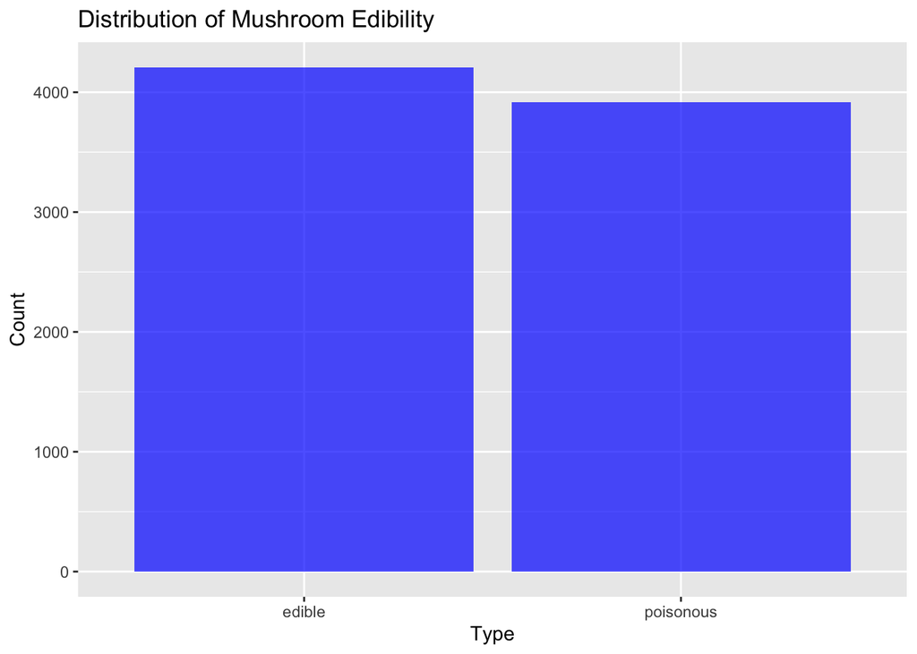

```r
# Visualize the distribution of edibility
ggplot(mushrooms, aes(x = type)) +
  geom_bar(fill = "blue", alpha = 0.7) +
  labs(title = "Distribution of Mushroom Edibility",
       x = "Type",
       y = "Count")
```

We can see that there are a similar number of each type of mushroom. There are a few more edible than poisonous ones. Now we are going to explore other variables of the dataset in relation with our target variable (type):

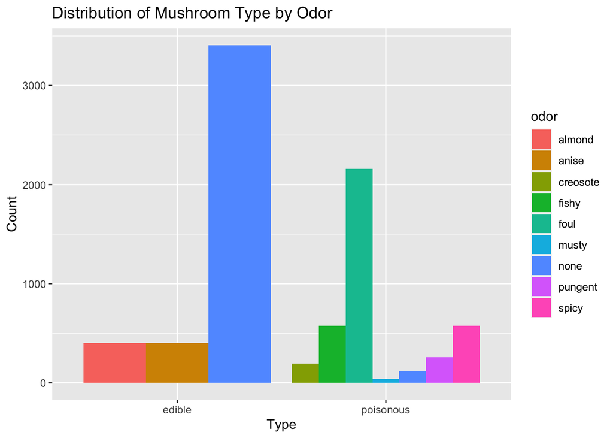

```r
ggplot(mushrooms, aes(x = type, fill = odor)) +
  geom_bar(position = "dodge") +
  labs(title = "Distribution of Mushroom Type by Odor",
       x = "Type",
       y = "Count")
```

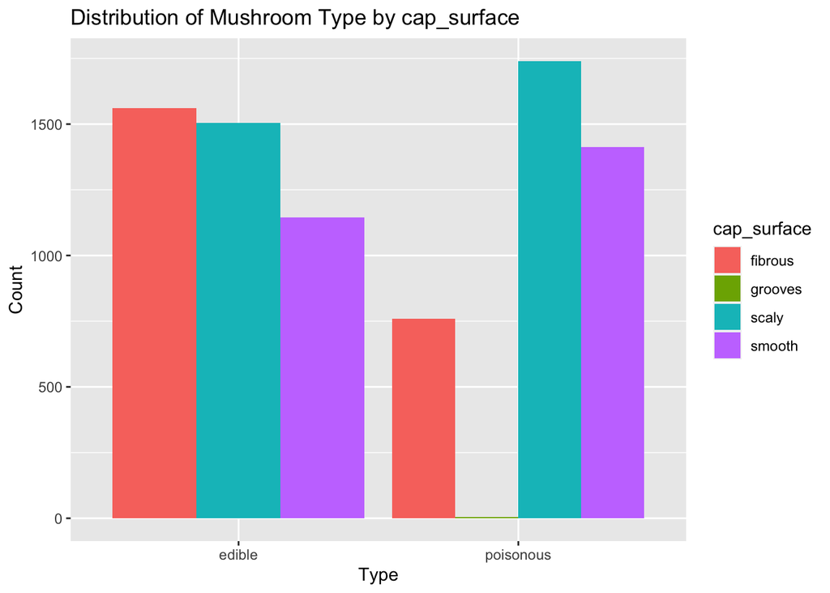

```r
ggplot(mushrooms, aes(x = type, fill = cap_surface)) +
  geom_bar(position = "dodge") +
  labs(title = "Distribution of Mushroom Type by cap_surface",
       x = "Type",
       y = "Count")
```

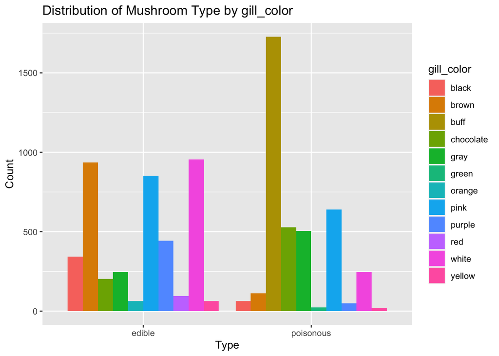

```r
ggplot(mushrooms, aes(x = type, fill = gill_color)) +
  geom_bar(position = "dodge") +
  labs(title = "Distribution of Mushroom Type by gill_color",
       x = "Type",
       y = "Count")
```

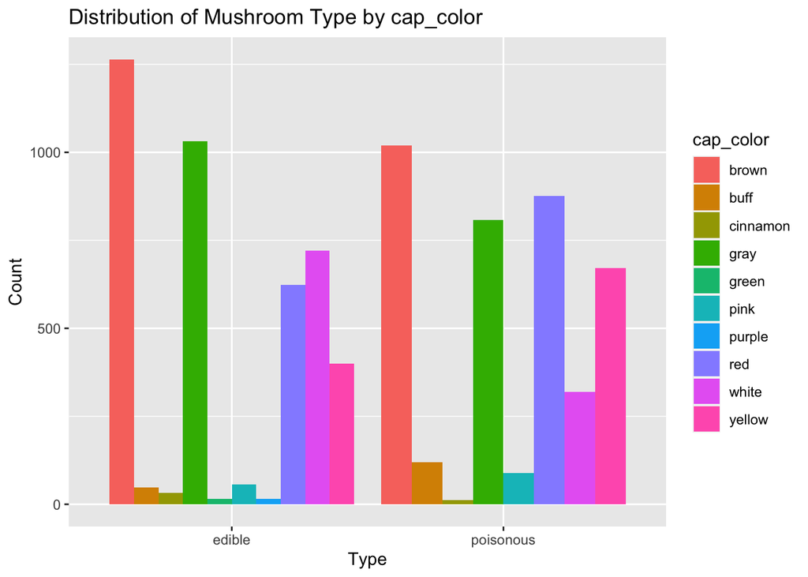

```r
ggplot(mushrooms, aes(x = type, fill = cap_color)) +
  geom_bar(position = "dodge") +
  labs(title = "Distribution of Mushroom Type by cap_color",
       x = "Type",
       y = "Count")
```

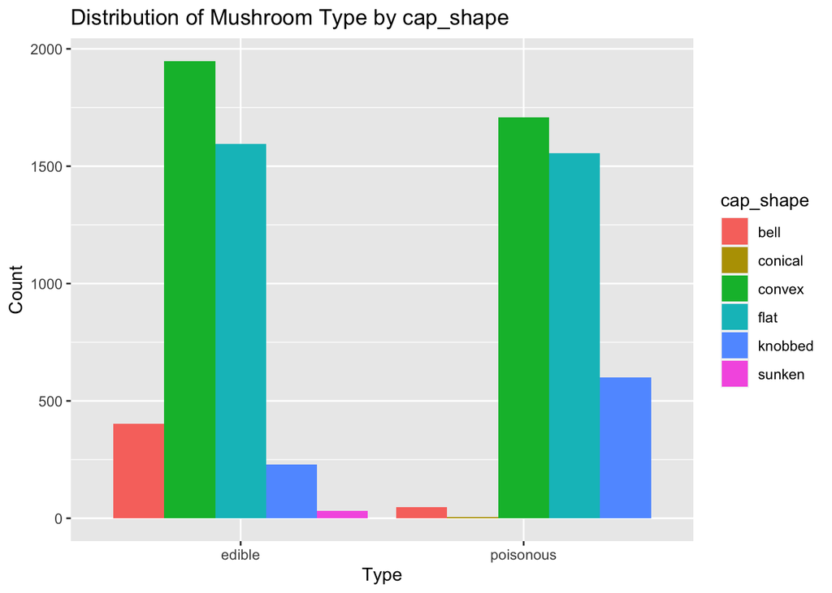

```r
ggplot(mushrooms, aes(x = type, fill = cap_shape)) +
  geom_bar(position = "dodge") +
  labs(title = "Distribution of Mushroom Type by cap_shape",
       x = "Type",
       y = "Count")
```

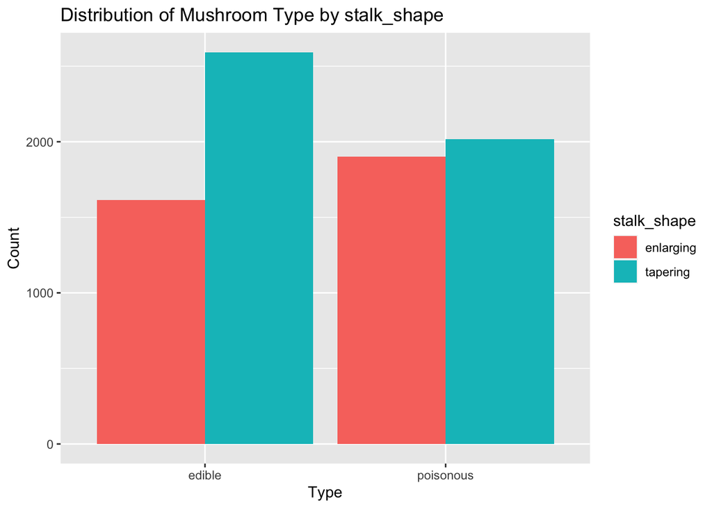

```r
ggplot(mushrooms, aes(x = type, fill = stalk_shape)) +
  geom_bar(position = "dodge") +
  labs(title = "Distribution of Mushroom Type by stalk_shape",
       x = "Type",
       y = "Count")
```

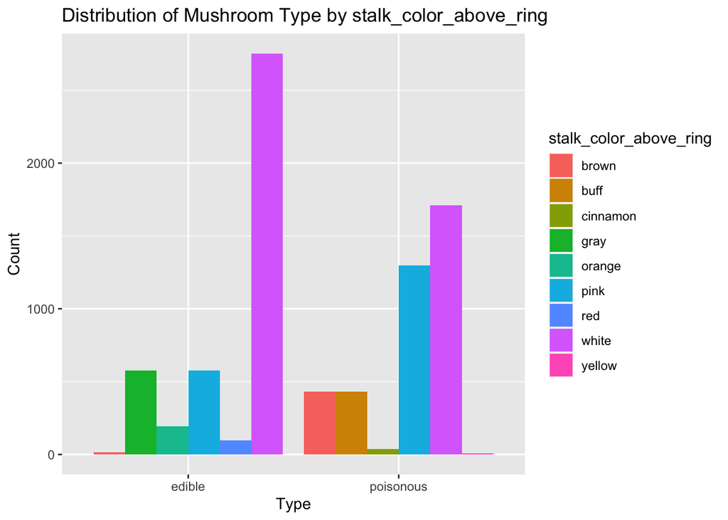

```r
ggplot(mushrooms, aes(x = type, fill = stalk_color_above_ring)) +
  geom_bar(position = "dodge") +
  labs(title = "Distribution of Mushroom Type by stalk_color_above_ring",
       x = "Type",
       y = "Count")
```

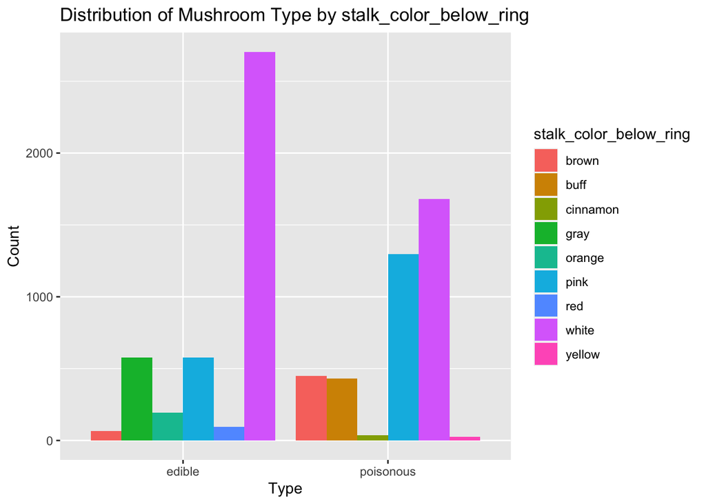

```r
ggplot(mushrooms, aes(x = type, fill = stalk_color_below_ring)) +
  geom_bar(position = "dodge") +
  labs(title = "Distribution of Mushroom Type by stalk_color_below_ring",
       x = "Type",
       y = "Count")
```

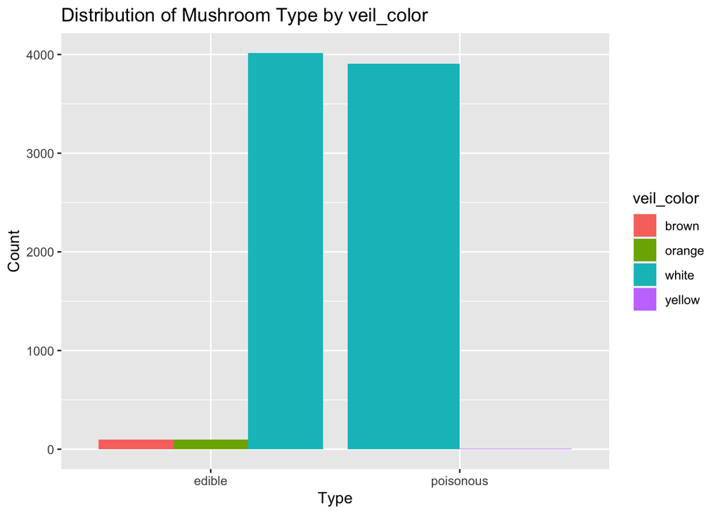

```r
ggplot(mushrooms, aes(x = type, fill = veil_color)) +
  geom_bar(position = "dodge") +
  labs(title = "Distribution of Mushroom Type by veil_color",
       x = "Type",
       y = "Count")
```

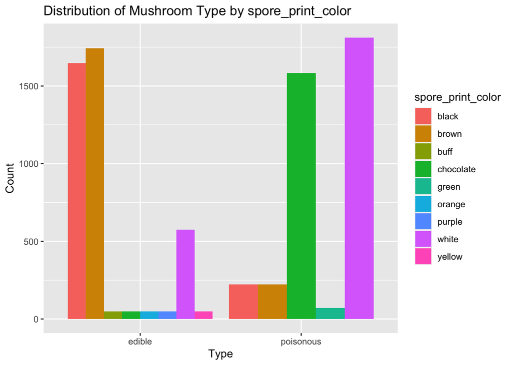

```r
ggplot(mushrooms, aes(x = type, fill = spore_print_color)) +
  geom_bar(position = "dodge") +
  labs(title = "Distribution of Mushroom Type by spore_print_color",
       x = "Type",
       y = "Count")
```

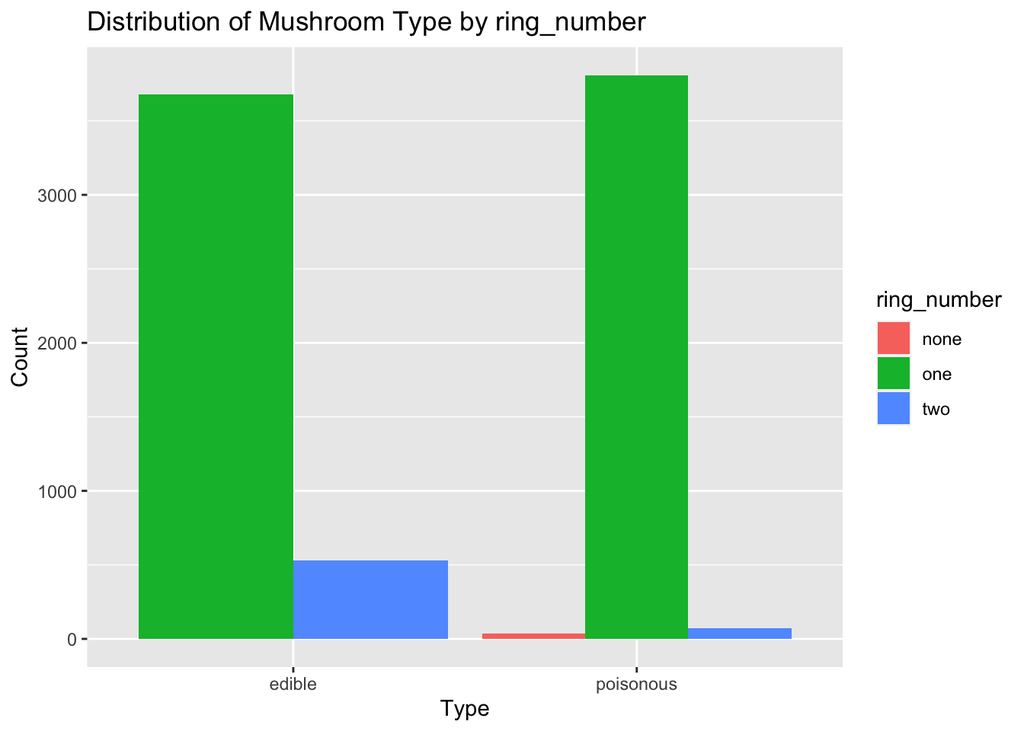

```r
ggplot(mushrooms, aes(x = type, fill = ring_number)) +
  geom_bar(position = "dodge") +
  labs(title = "Distribution of Mushroom Type by ring_number",
       x = "Type",
       y = "Count")
```

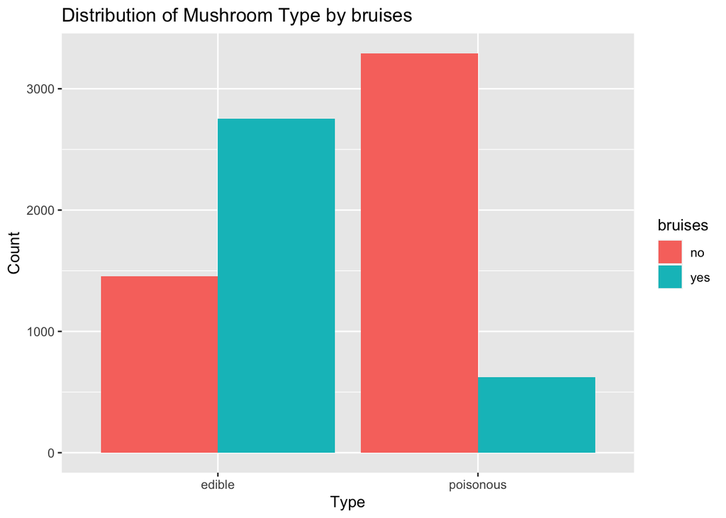

```r
ggplot(mushrooms, aes(x = type, fill = bruises)) +
  geom_bar(position = "dodge") +
  labs(title = "Distribution of Mushroom Type by bruises",
       x = "Type",
       y = "Count")
```

In all the above plots, we have seen possible characteristics that can be representative for an edible or poisonous mushrooms. Once we have checked the dataset, we can start with the association rules creation.

## Association Rule Mining

For the creation of the association rules we will use apriori algorithm. The Apriori algorithm requires the dataset to be in a transactional format, where each row represents a transaction and each column represents an item. In the context of this dataset, each row is a mushroom, and each column is a characteristic. The values in these columns should be binary (0 or 1), indicating the absence or presence of an attribute. For doing that, we will use the one-hot encoding, which converts categorical variables into a set of binary variables, each representing a category level.

```r
# Convert factors to character, if they are not already
mushrooms <- mushrooms %>% mutate_if(is.factor, as.character)

# One-Hot Encoding: Create binary columns for each category of each variable
mushroomsM <- mushrooms %>%
  mutate(row_id = row_number()) %>%  # Add a row identifier
  pivot_longer(cols = -row_id, names_to = "feature", values_to = "value") %>%
  unite("feature_value", feature, value, sep = "_") %>%  # Combine feature and value into a single column
  mutate(value = 1) %>%  # Set value to 1 (indicating presence)
  pivot_wider(names_from = "feature_value", values_from = "value", values_fill = list(value = 0)) %>%
  select(-row_id)  # Remove the row identifier

# Remove columns with only a single unique value as they are not informative
mushroomsM <- mushroomsM[, sapply(mushroomsM, function(x) length(unique(x)) > 1)]

# Convert numeric values to boolean (TRUE/FALSE)
mushroomsM <- mushroomsM %>% mutate(across(everything(), ~ .x == 1))

# View the first few rows and the structure of the transformed dataset
head(mushroomsM)
```

```
## # A tibble: 6 × 118
##   type_poisonous cap_shape_convex cap_surface_smooth cap_color_brown bruises_yes
##   <lgl>          <lgl>            <lgl>              <lgl>           <lgl>
## 1 TRUE           TRUE             TRUE               TRUE            TRUE
## 2 FALSE          TRUE             TRUE               FALSE           TRUE
## 3 FALSE          FALSE            TRUE               FALSE           TRUE
## 4 TRUE           TRUE             FALSE              FALSE           TRUE
## 5 FALSE          TRUE             TRUE               FALSE           FALSE
## 6 FALSE          TRUE             FALSE              FALSE           TRUE
## # ℹ 113 more variables: odor_pungent <lgl>, gill_attachment_free <lgl>,
## #   gill_spacing_close <lgl>, gill_size_narrow <lgl>, gill_color_black <lgl>,
## #   stalk_shape_enlarging <lgl>, stalk_root_equal <lgl>,
## #   stalk_surface_above_ring_smooth <lgl>,
## #   stalk_surface_below_ring_smooth <lgl>, stalk_color_above_ring_white <lgl>,
## #   stalk_color_below_ring_white <lgl>, veil_color_white <lgl>,
## #   ring_number_one <lgl>, ring_type_pendant <lgl>, …
```

```r
names(mushroomsM)
```

```
##   [1] "type_poisonous"                   "cap_shape_convex"
##   [3] "cap_surface_smooth"               "cap_color_brown"
##   [5] "bruises_yes"                      "odor_pungent"
##   [7] "gill_attachment_free"             "gill_spacing_close"
##   [9] "gill_size_narrow"                 "gill_color_black"
##  [11] "stalk_shape_enlarging"            "stalk_root_equal"
##  [13] "stalk_surface_above_ring_smooth"  "stalk_surface_below_ring_smooth"
##  [15] "stalk_color_above_ring_white"     "stalk_color_below_ring_white"
##  [17] "veil_color_white"                 "ring_number_one"
##  [19] "ring_type_pendant"                "spore_print_color_black"
##  [21] "population_scattered"             "habitat_urban"
##  [23] "type_edible"                      "cap_color_yellow"
##  [25] "odor_almond"                      "gill_size_broad"
##  [27] "stalk_root_club"                  "spore_print_color_brown"
##  [29] "population_numerous"              "habitat_grasses"
```

[output cut: 44 more lines]

```r
str(mushroomsM)
```

```
## tibble [8,124 × 118] (S3: tbl_df/tbl/data.frame)
##  $ type_poisonous                  : logi [1:8124] TRUE FALSE FALSE TRUE FALSE FALSE ...
##  $ cap_shape_convex                : logi [1:8124] TRUE TRUE FALSE TRUE TRUE TRUE ...
##  $ cap_surface_smooth              : logi [1:8124] TRUE TRUE TRUE FALSE TRUE FALSE ...
##  $ cap_color_brown                 : logi [1:8124] TRUE FALSE FALSE FALSE FALSE FALSE ...
##  $ bruises_yes                     : logi [1:8124] TRUE TRUE TRUE TRUE FALSE TRUE ...
##  $ odor_pungent                    : logi [1:8124] TRUE FALSE FALSE TRUE FALSE FALSE ...
##  $ gill_attachment_free            : logi [1:8124] TRUE TRUE TRUE TRUE TRUE TRUE ...
##  $ gill_spacing_close              : logi [1:8124] TRUE TRUE TRUE TRUE FALSE TRUE ...
##  $ gill_size_narrow                : logi [1:8124] TRUE FALSE FALSE TRUE FALSE FALSE ...
##  $ gill_color_black                : logi [1:8124] TRUE TRUE FALSE FALSE TRUE FALSE ...
##  $ stalk_shape_enlarging           : logi [1:8124] TRUE TRUE TRUE TRUE FALSE TRUE ...
##  $ stalk_root_equal                : logi [1:8124] TRUE FALSE FALSE TRUE TRUE FALSE ...
##  $ stalk_surface_above_ring_smooth : logi [1:8124] TRUE TRUE TRUE TRUE TRUE TRUE ...
##  $ stalk_surface_below_ring_smooth : logi [1:8124] TRUE TRUE TRUE TRUE TRUE TRUE ...
```

[output cut: 86 more lines]

As we can see, we have created columns for each characteristic. For exemple, if a mushroom has diferent cap_colors we have created a columns for each possible color, and each one is categorized with a 0 or 1. A 0 tells us that the mushroom has not this color and a 1 tells us that it has it. As we can see, we have removed all the columns where all the values where 1 or 0 because there are not valuable for the solution of the problem and the creation of the rules. As well, we have transformed all the 1 and 0 for TRUE and FALSE values. This is due to the transaction transformation that we will do now.

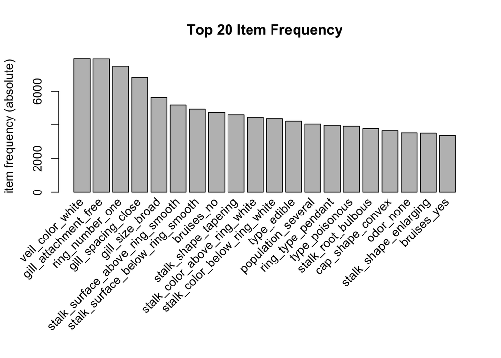

```r
# We convert the dataset labels to boolean
mushroomsM <- mushroomsM %>%
  mutate(across(everything(), as.logical))

# Now convert the data to a transaction format
transactions <- as(mushroomsM, "transactions")

## plot of top 20 most frequent items
itemFrequencyPlot(transactions, topN = 20, type="absolute", main="Top 20 Item Frequency")
```

```r
frequentItems <- eclat(transactions, parameter = list(support = 0.05)) # calculates support for frequent items
inspect(head(frequentItems))
```

[output not shown]

After transforming the modified mushroomsM dataset to transactions, now we are ready to create the rules:

```r
# Apply the Apriori algorithm
rules <- apriori(transactions,
                 parameter = list(supp = 0.05, conf = 0.5, minlen = 2, maxlen = 3))
```

```
## Apriori
##
## Parameter specification:
##  confidence minval smax arem  aval originalSupport maxtime support minlen
##         0.5    0.1    1 none FALSE            TRUE       5    0.05      2
##  maxlen target  ext
##       3  rules TRUE
##
## Algorithmic control:
##  filter tree heap memopt load sort verbose
##     0.1 TRUE TRUE  FALSE TRUE    2    TRUE
##
## Absolute minimum support count: 406
##
## set item appearances ...[0 item(s)] done [0.00s].
## set transactions ...[118 item(s), 8124 transaction(s)] done [0.00s].
## sorting and recoding items ... [72 item(s)] done [0.00s].
## creating transaction tree ... done [0.00s].
## checking subsets of size 1 2 3
```

```
##  done [0.02s].
## writing ... [17662 rule(s)] done [0.00s].
## creating S4 object  ... done [0.00s].
```

```r
# For a better treatment, we transform the rules to a dataframe
rules_df <- as(rules, "data.frame")

# Inspect top rules
inspect(head(rules, n = 10))
```

```
##      lhs                              rhs                                 support confidence   coverage     lift count
## [1]  {gill_color_black}            => {stalk_color_below_ring_white}   0.05022157          1 0.05022157 1.853102   408
## [2]  {gill_color_black}            => {stalk_color_above_ring_white}   0.05022157          1 0.05022157 1.819892   408
## [3]  {gill_color_black}            => {ring_number_one}                0.05022157          1 0.05022157 1.084936   408
## [4]  {gill_color_black}            => {gill_attachment_free}           0.05022157          1 0.05022157 1.026535   408
## [5]  {gill_color_black}            => {veil_color_white}               0.05022157          1 0.05022157 1.025240   408
## [6]  {stalk_color_below_ring_buff} => {ring_type_large}                0.05317578          1 0.05317578 6.268519   432
## [7]  {stalk_color_below_ring_buff} => {spore_print_color_chocolate}    0.05317578          1 0.05317578 4.977941   432
## [8]  {stalk_color_below_ring_buff} => {odor_foul}                      0.05317578          1 0.05317578 3.761111   432
## [9]  {stalk_color_below_ring_buff} => {stalk_surface_below_ring_silky} 0.05317578          1 0.05317578 3.526042   432
## [10] {stalk_color_below_ring_buff} => {stalk_surface_above_ring_silky} 0.05317578          1 0.05317578 3.424958   432
```

## Analysis of Rules

Now, we are going to analize the set of rules generated. We are going to try to identify the onese that are more important and the onse that are less. As well, we will try to see if there are any redundace between the rules and decide if we should delete some of them. Before doing that, we must understand what the parameters for the apriori algorithm means.

- **Support** : indicates how frequently the itemset appears in the dataset.
- **Confidence** : measures how often items in Y appear in transactions containing X.
- **Lift** : shows how much more often X and Y occur together than expected if they were statistically independent.

Now let’s focus on our target variable, the edibility of the mushrooms. We are going to filter the rules to focus only on those related to edibility:

```r
edible_rules <- subset(rules, rhs %pin% "type_edible")
poisonous_rules <- subset(rules, rhs %pin% "type_poisonous")

inspect(head(edible_rules, n = 10))
```

```
##      lhs                                   rhs           support    confidence
## [1]  {gill_color_purple}                => {type_edible} 0.05465288 0.9024390
## [2]  {stalk_surface_above_ring_fibrous} => {type_edible} 0.05022157 0.7391304
## [3]  {stalk_root_club}                  => {type_edible} 0.06302314 0.9208633
## [4]  {stalk_color_above_ring_gray}      => {type_edible} 0.07090103 1.0000000
## [5]  {stalk_color_below_ring_gray}      => {type_edible} 0.07090103 1.0000000
## [6]  {ring_number_two}                  => {type_edible} 0.06499261 0.8800000
## [7]  {stalk_surface_below_ring_fibrous} => {type_edible} 0.05612999 0.7600000
## [8]  {cap_color_white}                  => {type_edible} 0.08862629 0.6923077
## [9]  {gill_color_brown}                 => {type_edible} 0.11521418 0.8931298
## [10] {stalk_root_equal}                 => {type_edible} 0.10635155 0.7714286
##      coverage   lift     count
## [1]  0.06056130 1.742256 444
## [2]  0.06794682 1.426971 408
## [3]  0.06843919 1.777826 512
## [4]  0.07090103 1.930608 576
## [5]  0.07090103 1.930608 576
## [6]  0.07385524 1.698935 528
## [7]  0.07385524 1.467262 456
## [8]  0.12801576 1.336575 720
## [9]  0.12900049 1.724284 936
## [10] 0.13786312 1.489326 864
```

```r
inspect(head(poisonous_rules, n = 10))
```

```
##      lhs                               rhs              support    confidence
## [1]  {stalk_color_below_ring_buff}  => {type_poisonous} 0.05317578 1.0000000
## [2]  {stalk_color_above_ring_buff}  => {type_poisonous} 0.05317578 1.0000000
## [3]  {stalk_color_above_ring_brown} => {type_poisonous} 0.05317578 0.9642857
## [4]  {stalk_color_below_ring_brown} => {type_poisonous} 0.05514525 0.8750000
## [5]  {odor_spicy}                   => {type_poisonous} 0.07090103 1.0000000
## [6]  {odor_fishy}                   => {type_poisonous} 0.07090103 1.0000000
## [7]  {gill_color_chocolate}         => {type_poisonous} 0.06499261 0.7213115
## [8]  {gill_color_gray}              => {type_poisonous} 0.06203840 0.6702128
## [9]  {cap_shape_knobbed}            => {type_poisonous} 0.07385524 0.7246377
## [10] {habitat_leaves}               => {type_poisonous} 0.07287051 0.7115385
##      coverage   lift     count
## [1]  0.05317578 2.074566 432
## [2]  0.05317578 2.074566 432
## [3]  0.05514525 2.000474 432
## [4]  0.06302314 1.815245 448
## [5]  0.07090103 2.074566 576
## [6]  0.07090103 2.074566 576
## [7]  0.09010340 1.496408 528
## [8]  0.09256524 1.390401 504
## [9]  0.10192024 1.503309 600
## [10] 0.10241260 1.476133 592
```

### Most Significant Rules

We will now identify the most significant rules, focusing on those with the highest lift, as they indicate a strong relationship between the antecedent and consequent.

```r
# Sorting edible rules by lift
sorted_edible_by_lift <- sort(edible_rules, by = "lift", decreasing = TRUE)
inspect(head(sorted_edible_by_lift, n = 20))
```

```
##      lhs                                   rhs              support confidence   coverage     lift count
## [1]  {stalk_color_above_ring_gray}      => {type_edible} 0.07090103          1 0.07090103 1.930608   576
## [2]  {stalk_color_below_ring_gray}      => {type_edible} 0.07090103          1 0.07090103 1.930608   576
## [3]  {bruises_yes,
##       gill_color_purple}                => {type_edible} 0.05317578          1 0.05317578 1.930608   432
## [4]  {odor_none,
##       gill_color_purple}                => {type_edible} 0.05465288          1 0.05465288 1.930608   444
## [5]  {stalk_shape_tapering,
##       gill_color_purple}                => {type_edible} 0.05317578          1 0.05317578 1.930608   432
## [6]  {gill_size_broad,
##       gill_color_purple}                => {type_edible} 0.05317578          1 0.05317578 1.930608   432
## [7]  {gill_spacing_crowded,
##       stalk_surface_above_ring_fibrous} => {type_edible} 0.05022157          1 0.05022157 1.930608   408
## [8]  {ring_type_evanescent,
##       stalk_surface_above_ring_fibrous} => {type_edible} 0.05022157          1 0.05022157 1.930608   408
## [9]  {odor_none,
##       stalk_surface_above_ring_fibrous} => {type_edible} 0.05022157          1 0.05022157 1.930608   408
## [10] {bruises_no,
##       stalk_surface_above_ring_fibrous} => {type_edible} 0.05022157          1 0.05022157 1.930608   408
## [11] {bruises_yes,
##       stalk_root_club}                  => {type_edible} 0.06302314          1 0.06302314 1.930608   512
## [12] {ring_type_pendant,
##       stalk_root_club}                  => {type_edible} 0.06302314          1 0.06302314 1.930608   512
## [13] {stalk_color_below_ring_white,
##       stalk_root_club}                  => {type_edible} 0.06302314          1 0.06302314 1.930608   512
## [14] {stalk_color_above_ring_white,
##       stalk_root_club}                  => {type_edible} 0.06302314          1 0.06302314 1.930608   512
## [15] {stalk_surface_below_ring_smooth,
##       stalk_root_club}                  => {type_edible} 0.06302314          1 0.06302314 1.930608   512
## [16] {stalk_surface_above_ring_smooth,
##       stalk_root_club}                  => {type_edible} 0.06302314          1 0.06302314 1.930608   512
## [17] {habitat_woods,
##       stalk_color_above_ring_gray}      => {type_edible} 0.07090103          1 0.07090103 1.930608   576
## [18] {bruises_yes,
##       stalk_color_above_ring_gray}      => {type_edible} 0.07090103          1 0.07090103 1.930608   576
## [19] {odor_none,
##       stalk_color_above_ring_gray}      => {type_edible} 0.07090103          1 0.07090103 1.930608   576
## [20] {stalk_root_bulbous,
##       stalk_color_above_ring_gray}      => {type_edible} 0.07090103          1 0.07090103 1.930608   576
```

```r
# Sorting poisonous rules by lift
sorted_poisonous_by_lift <- sort(poisonous_rules, by = "lift", decreasing = TRUE)
inspect(head(sorted_poisonous_by_lift, n = 20))
```

```
##      lhs                                  rhs                 support confidence   coverage     lift count
## [1]  {stalk_color_below_ring_buff}     => {type_poisonous} 0.05317578          1 0.05317578 2.074566   432
## [2]  {stalk_color_above_ring_buff}     => {type_poisonous} 0.05317578          1 0.05317578 2.074566   432
## [3]  {odor_spicy}                      => {type_poisonous} 0.07090103          1 0.07090103 2.074566   576
## [4]  {odor_fishy}                      => {type_poisonous} 0.07090103          1 0.07090103 2.074566   576
## [5]  {ring_type_large}                 => {type_poisonous} 0.15952733          1 0.15952733 2.074566  1296
## [6]  {gill_color_buff}                 => {type_poisonous} 0.21270310          1 0.21270310 2.074566  1728
## [7]  {odor_foul}                       => {type_poisonous} 0.26587888          1 0.26587888 2.074566  2160
## [8]  {stalk_color_below_ring_buff,
##       ring_type_large}                 => {type_poisonous} 0.05317578          1 0.05317578 2.074566   432
## [9]  {stalk_color_below_ring_buff,
##       spore_print_color_chocolate}     => {type_poisonous} 0.05317578          1 0.05317578 2.074566   432
## [10] {odor_foul,
##       stalk_color_below_ring_buff}     => {type_poisonous} 0.05317578          1 0.05317578 2.074566   432
## [11] {stalk_surface_below_ring_silky,
##       stalk_color_below_ring_buff}     => {type_poisonous} 0.05317578          1 0.05317578 2.074566   432
## [12] {stalk_surface_above_ring_silky,
##       stalk_color_below_ring_buff}     => {type_poisonous} 0.05317578          1 0.05317578 2.074566   432
## [13] {stalk_shape_enlarging,
##       stalk_color_below_ring_buff}     => {type_poisonous} 0.05317578          1 0.05317578 2.074566   432
## [14] {stalk_root_bulbous,
##       stalk_color_below_ring_buff}     => {type_poisonous} 0.05317578          1 0.05317578 2.074566   432
## [15] {bruises_no,
##       stalk_color_below_ring_buff}     => {type_poisonous} 0.05317578          1 0.05317578 2.074566   432
## [16] {gill_size_broad,
##       stalk_color_below_ring_buff}     => {type_poisonous} 0.05317578          1 0.05317578 2.074566   432
## [17] {gill_spacing_close,
##       stalk_color_below_ring_buff}     => {type_poisonous} 0.05317578          1 0.05317578 2.074566   432
## [18] {ring_number_one,
##       stalk_color_below_ring_buff}     => {type_poisonous} 0.05317578          1 0.05317578 2.074566   432
## [19] {gill_attachment_free,
##       stalk_color_below_ring_buff}     => {type_poisonous} 0.05317578          1 0.05317578 2.074566   432
## [20] {veil_color_white,
##       stalk_color_below_ring_buff}     => {type_poisonous} 0.05317578          1 0.05317578 2.074566   432
```

### Least significant rules

Similarly, we will look at the least significant rules, which might be less reliable due to lower confidence or lift.

```r
# Sorting edible rules by lift for least significant rules
inspect(tail(sorted_edible_by_lift, n = 10))
```

```
##      lhs                                rhs             support confidence  coverage      lift count
## [1]  {gill_attachment_free,
##       veil_color_white}              => {type_edible} 0.4943378  0.5079686 0.9731659 0.9806885  4016
## [2]  {gill_attachment_free}          => {type_edible} 0.4943378  0.5074551 0.9741507 0.9796971  4016
## [3]  {veil_color_white}              => {type_edible} 0.4943378  0.5068147 0.9753816 0.9784608  4016
## [4]  {cap_shape_flat}                => {type_edible} 0.1964549  0.5063452 0.3879862 0.9775542  1596
## [5]  {stalk_color_above_ring_white,
##       ring_type_evanescent}          => {type_edible} 0.1122600  0.5044248 0.2225505 0.9738467   912
## [6]  {stalk_shape_enlarging,
##       gill_size_broad}               => {type_edible} 0.1752831  0.5035361 0.3481044 0.9721309  1424
## [7]  {gill_spacing_close,
##       stalk_root_bulbous}            => {type_edible} 0.2186115  0.5034014 0.4342688 0.9718709  1776
## [8]  {ring_number_one,
##       cap_shape_flat}                => {type_edible} 0.1861152  0.5006623 0.3717381 0.9665827  1512
## [9]  {stalk_color_below_ring_white,
##       ring_type_evanescent}          => {type_edible} 0.1063516  0.5000000 0.2127031 0.9653042   864
## [10] {cap_surface_scaly,
##       stalk_shape_tapering}          => {type_edible} 0.1063516  0.5000000 0.2127031 0.9653042   864
```

```r
# Sorting poisonous rules by lift for least significant rules
inspect(tail(sorted_poisonous_by_lift, n = 10))
```

```
##      lhs                                rhs                support confidence  coverage     lift count
## [1]  {cap_color_brown,
##       stalk_shape_tapering}          => {type_poisonous} 0.1063516  0.5094340 0.2087642 1.056854   864
## [2]  {cap_shape_convex,
##       stalk_root_bulbous}            => {type_poisonous} 0.1211226  0.5093168 0.2378139 1.056611   984
## [3]  {cap_color_brown,
##       gill_spacing_close}            => {type_poisonous} 0.1255539  0.5089820 0.2466765 1.055917  1020
## [4]  {gill_spacing_close,
##       stalk_color_above_ring_white}  => {type_poisonous} 0.1979321  0.5088608 0.3889710 1.055665  1608
## [5]  {ring_number_one}               => {type_poisonous} 0.4687346  0.5085470 0.9217134 1.055014  3808
## [6]  {gill_spacing_close,
##       stalk_color_below_ring_white}  => {type_poisonous} 0.1939931  0.5038363 0.3850320 1.045242  1576
## [7]  {veil_color_white,
##       cap_shape_flat}                => {type_poisonous} 0.1912851  0.5009671 0.3818316 1.039289  1554
## [8]  {gill_attachment_free,
##       cap_shape_flat}                => {type_poisonous} 0.1907927  0.5003228 0.3813392 1.037953  1550
## [9]  {stalk_color_below_ring_white,
##       ring_type_evanescent}          => {type_poisonous} 0.1063516  0.5000000 0.2127031 1.037283   864
## [10] {cap_surface_scaly,
##       stalk_shape_tapering}          => {type_poisonous} 0.1063516  0.5000000 0.2127031 1.037283   864
```

### Analyzing Redundancy in Rules

Redundant rules are those that convey similar information. Identifying these can make our rule set more concise and easier to interpret. We are going to try to find rules that have similar antecedents and slightly different consequents. This type of rules are not useful for our set of rules. To find this type of rules, we will use this code to find possible candidates:

First, we have separate the antecedents form the consequences.

```r
# Extraer antecedentes y consecuentes como strings
rules_df$antecedents <- sapply(strsplit(rules_df$rules, " => "), `[[`, 1)
rules_df$consequents <- sapply(strsplit(rules_df$rules, " => "), `[[`, 2)

# Ver el dataframe resultante
head(rules_df)
```

```
##                                                  rules    support confidence
## 1 {gill_color_black} => {stalk_color_below_ring_white} 0.05022157          1
## 2 {gill_color_black} => {stalk_color_above_ring_white} 0.05022157          1
## 3              {gill_color_black} => {ring_number_one} 0.05022157          1
## 4         {gill_color_black} => {gill_attachment_free} 0.05022157          1
## 5             {gill_color_black} => {veil_color_white} 0.05022157          1
## 6   {stalk_color_below_ring_buff} => {ring_type_large} 0.05317578          1
##     coverage     lift count                   antecedents
## 1 0.05022157 1.853102   408            {gill_color_black}
## 2 0.05022157 1.819892   408            {gill_color_black}
## 3 0.05022157 1.084936   408            {gill_color_black}
## 4 0.05022157 1.026535   408            {gill_color_black}
## 5 0.05022157 1.025240   408            {gill_color_black}
## 6 0.05317578 6.268519   432 {stalk_color_below_ring_buff}
##                      consequents
## 1 {stalk_color_below_ring_white}
## 2 {stalk_color_above_ring_white}
## 3              {ring_number_one}
## 4         {gill_attachment_free}
## 5             {veil_color_white}
## 6              {ring_type_large}
```

Then, we have group the rules by antecedents.

```r
# Group rules by antecedents
grouped_rules <- rules_df %>%
  group_by(antecedents) %>%
  summarize(consequents_list = list(consequents),
            rules_list = list(rules),
            .groups = 'drop')

# View grouped rules
head(grouped_rules)
```

```
## # A tibble: 6 × 3
##   antecedents                       consequents_list rules_list
##   <chr>                             <list>           <list>
## 1 {bruises_no,cap_color_red}        <chr [14]>       <chr [14]>
## 2 {bruises_no,cap_shape_flat}       <chr [11]>       <chr [11]>
## 3 {bruises_no,cap_shape_knobbed}    <chr [13]>       <chr [13]>
## 4 {bruises_no,cap_surface_fibrous}  <chr [14]>       <chr [14]>
## 5 {bruises_no,gill_color_buff}      <chr [23]>       <chr [23]>
## 6 {bruises_no,gill_color_chocolate} <chr [13]>       <chr [13]>
```

Finaly, we group rules with more than one consequence

```r
# Filter groups with more than one consequence
varied_consequents <- grouped_rules %>%
  filter(lengths(consequents_list) > 1)

# View results
head(varied_consequents)
```

```
## # A tibble: 6 × 3
##   antecedents                       consequents_list rules_list
##   <chr>                             <list>           <list>
## 1 {bruises_no,cap_color_red}        <chr [14]>       <chr [14]>
## 2 {bruises_no,cap_shape_flat}       <chr [11]>       <chr [11]>
## 3 {bruises_no,cap_shape_knobbed}    <chr [13]>       <chr [13]>
## 4 {bruises_no,cap_surface_fibrous}  <chr [14]>       <chr [14]>
## 5 {bruises_no,gill_color_buff}      <chr [23]>       <chr [23]>
## 6 {bruises_no,gill_color_chocolate} <chr [13]>       <chr [13]>
```

The *varied_consequents* object, is a dataframe that groups association rules based on their antecedents. Each row in this dataframe represents a group of rules that share the same antecedents. Here’s what each column in *varied_consequents* represents:

- **antecedents**: This column contains the antecedents (left-hand side, LHS) of the association rules. Each entry in this column is a set of items that appear together on the left-hand side of the association rules. All items in a set of antecedents are the same for the rules within that group.
- **consequents_list**: This column stores a list of lists of the consequents (right-hand side, RHS) of each rule that shares the same antecedents. Each entry in this column is a list containing all the different sets of items that appear as consequents in the group of rules with those specific antecedents.
- **rules_list**: Similar to consequents_list, this column is a list of the complete rules (in their original format) that belong to each antecedent group. It’s useful if you want to refer back to the complete rule with its support, confidence, lift, etc.

Let’s show an exemple of using of the dataframe we have created:

```r
# Look for any specific row we want to look for
specific_row_number <- 10

# Extracting the antecedent
specific_antecedents <- varied_consequents$antecedents[[specific_row_number]]

# Extracting the list of consequents from the specific row
specific_consequents_list <- varied_consequents$consequents_list[[specific_row_number]]

# Extracting the list of rules from the specific row
specific_rules_list <- varied_consequents$rules_list[[specific_row_number]]

# Printing the full lists
print(specific_antecedents)
```

```
## [1] "{bruises_no,habitat_leaves}"
```

```r
cat("\n\n\n")
```

```r
print(specific_consequents_list)
```

```
##  [1] "{gill_color_buff}"                 "{cap_color_brown}"
##  [3] "{spore_print_color_white}"         "{stalk_root_missing}"
##  [5] "{gill_size_narrow}"                "{cap_surface_smooth}"
##  [7] "{ring_type_evanescent}"            "{type_poisonous}"
##  [9] "{population_several}"              "{stalk_shape_tapering}"
## [11] "{stalk_surface_below_ring_smooth}" "{stalk_surface_above_ring_smooth}"
## [13] "{gill_spacing_close}"              "{ring_number_one}"
## [15] "{gill_attachment_free}"            "{veil_color_white}"
```

```r
cat("\n\n\n")
```

```r
print(specific_rules_list)
```

```
##  [1] "{bruises_no,habitat_leaves} => {gill_color_buff}"
##  [2] "{bruises_no,habitat_leaves} => {cap_color_brown}"
##  [3] "{bruises_no,habitat_leaves} => {spore_print_color_white}"
##  [4] "{bruises_no,habitat_leaves} => {stalk_root_missing}"
##  [5] "{bruises_no,habitat_leaves} => {gill_size_narrow}"
##  [6] "{bruises_no,habitat_leaves} => {cap_surface_smooth}"
##  [7] "{bruises_no,habitat_leaves} => {ring_type_evanescent}"
##  [8] "{bruises_no,habitat_leaves} => {type_poisonous}"
##  [9] "{bruises_no,habitat_leaves} => {population_several}"
## [10] "{bruises_no,habitat_leaves} => {stalk_shape_tapering}"
## [11] "{bruises_no,habitat_leaves} => {stalk_surface_below_ring_smooth}"
## [12] "{bruises_no,habitat_leaves} => {stalk_surface_above_ring_smooth}"
## [13] "{bruises_no,habitat_leaves} => {gill_spacing_close}"
## [14] "{bruises_no,habitat_leaves} => {ring_number_one}"
## [15] "{bruises_no,habitat_leaves} => {gill_attachment_free}"
## [16] "{bruises_no,habitat_leaves} => {veil_color_white}"
```

## Interpretation of Rules

The interpretation of these rules can provide valuable insights into the characteristics of mushrooms that are commonly associated with being edible or poisonous. We will discuss the implication of 3 of the top 10 rules from *sorted_edible_by_lift* and 3 more from *sorted_poisonous_by_lift* and we will see haw important are they to identify an edible or poisonous mushroom.

```r
inspect(sorted_edible_by_lift[1])
```

```
##     lhs                              rhs           support    confidence
## [1] {stalk_color_above_ring_gray} => {type_edible} 0.07090103 1
##     coverage   lift     count
## [1] 0.07090103 1.930608 576
```

This rule suggests that mushrooms with a gray color above the ring on the stalk are likely to be edible. The confidence of 1 indicates that 100% of the observations with this characteristic in the dataset were edible mushrooms. This implicates that the presence of a gray color above the ring could be a strong indicator of an edible mushroom. This characteristic can be used as a quick visual guide when identifying safe mushrooms to consume.

```r
inspect(sorted_edible_by_lift[3])
```

```
##     lhs                                 rhs           support    confidence
## [1] {bruises_yes, gill_color_purple} => {type_edible} 0.05317578 1
##     coverage   lift     count
## [1] 0.05317578 1.930608 432
```

Mushrooms that have bruises and purple-colored gills are found to be edible. This combination of features seems to be a reliable indicator of edibility, as evidenced by the perfect confidence score. The rule can inform that the combination of these two traits, bruising and purple gills, is a distinctive marker of non-poisonous varieties.

```r
inspect(sorted_edible_by_lift[7])
```

```
##     lhs                                   rhs              support confidence   coverage     lift count
## [1] {gill_spacing_crowded,
##      stalk_surface_above_ring_fibrous} => {type_edible} 0.05022157          1 0.05022157 1.930608   408
```

The rule indicates that mushrooms with crowded gill spacing and a fibrous surface above the ring are edible. The consistent confidence of 1 across these rules suggests that this particular morphological profile is exclusively associated with edible mushrooms in the dataset. This rule could be particularly useful in educational materials for those learning about mushroom harvesting, emphasizing the significance of gill spacing and stalk surface texture in the identification process.

Now, let’s analize the implications of some rules from *sorted_poisonous_by_lift*

```r
inspect(sorted_poisonous_by_lift[1])
```

```
##     lhs                              rhs              support    confidence
## [1] {stalk_color_below_ring_buff} => {type_poisonous} 0.05317578 1
##     coverage   lift     count
## [1] 0.05317578 2.074566 432
```

This rule indicates that mushrooms with a buff color below the mushroom’s ring on the stalk are identified as poisonous. The confidence level of 1 suggests that all mushrooms with this feature in the dataset are poisonous. This trait could be a strong visual cue for identifying potentially harmful mushrooms, serving as a critical warning sign.

```r
inspect(sorted_poisonous_by_lift[3])
```

```
##     lhs             rhs              support    confidence coverage   lift
## [1] {odor_spicy} => {type_poisonous} 0.07090103 1          0.07090103 2.074566
##     count
## [1] 576
```

Mushrooms that emit a spicy odor are classified as poisonous. The rule’s perfect confidence score implies that spicy odor is a definitive marker of a mushroom’s toxicity within the dataset. The odor of a mushroom is a significant indicator of its safety. Educating mushroom pickers about the correlation between a spicy smell and toxicity could be lifesaving, emphasizing the need to trust one’s sense of smell when foraging.

```r
inspect(sorted_poisonous_by_lift[7])
```

```
##     lhs            rhs              support   confidence coverage  lift
## [1] {odor_foul} => {type_poisonous} 0.2658789 1          0.2658789 2.074566
##     count
## [1] 2160
```

The presence of a foul odor is directly associated with poisonous mushrooms. The dataset shows that mushrooms with a foul smell are invariably poisonous, as denoted by the confidence score of 1. A foul smell is a universally recognized sign of potential danger in food items, and this rule reinforces that intuition in the context of mushrooms. This characteristic can be used as a simple heuristic for avoiding poisonous mushrooms during collection.

## Conclusion of Rule Analysis

In this assignment, we started a process of association rule mining, applying the Apriori algorithm to a dataset of mushroom characteristics. The goal was to recognize patterns that distinguish edible mushrooms from poisonous ones.

We began with data preprocessing, which involved encoding categorical variables through one-hot encoding, resulting in a binary representation suitable for association rule mining. This step was crucial as it prepared our data for the subsequent analysis, ensuring each characteristic of the mushrooms was appropriately represented.

Our analysis extracted several significant rules with high lift values, which underscored the strong association between certain mushroom characteristics and their classification as edible or poisonous. For example, we found that mushrooms with a grey stalk color above the ring or a spicy odor are highly likely to be edible or poisonous, respectively.

In conclusion, this assignment allowed us to achieve our objective of distinguishing between edible and poisonous mushrooms through data mining techniques. Doing all the process was really useful for improving the way we do the data preparation, parameter tuning, and the interpretation of results.

Reflecting on the assignment, it was particularly interesting to see how specific mushroom traits are strongly correlated with edibility. The fact that certain combinations of features such as odor and gill color are exclusive to either edible or poisonous mushrooms was a notable finding.